# Homework 4: Classification with Logistic Regression & LASSO

## Exercise 2: `model_1` interpretation & prediction

`model_1` models whether or not it will rain *tomorrow* by whether or not it rained *today*, a *categorical* predictor. Let’s explore.

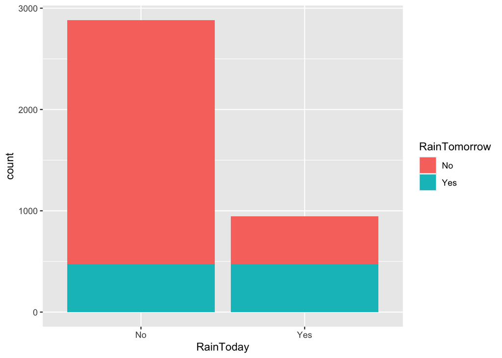

```r
# Plot the relationship
ggplot(sydney, aes(x = RainToday, fill = RainTomorrow)) +
  geom_bar()
```

### Part a

You built `model_1` in Exercise 1. Print the coefficients table here.

### Part b

Interpret the `RainTodayYes` coefficient on the LOG(ODDS) scale.

### Part c

Interpret the `RainTodayYes` coefficient on the ODDS scale.

### Part d

Consider two new data points:

```r
new_days <- data.frame(Day = c(1, 2), RainToday = c("No", "Yes"))
new_days
```

```
  Day RainToday
1   1        No
2   2       Yes
```

Use `model_1` to calculate the probability of rain tomorrow for these new data points. *Do this from scratch first (using the model coefficients), and then confirm your calculations using a built-in R function.*

```r
# Probability of rain on Day 1 (calculate from scratch)

# Probability of rain on Day 2 (calculate from scratch)

# Confirm calculations using a built-in R function
```

### Part e

Suppose we used `model_1` with a 0.5 probability threshold to classify whether it rains tomorrow:

- If the probability of rain tomorrow is at least 0.5, predict rain tomorrow.
- Otherwise, predict no rain.

**Fill in the blank below** to translate this rule into a statement about `RainToday`. (Remember that this predictor can only be Yes or No!)

- If ___, predict rain tomorrow.
- Otherwise, predict no rain.

## Exercise 3: `model_1` in-sample evaluation

How good is the *in-sample* performance of our above `model_1` classification rule? Let’s explore.

### Part a

Obtain the in-sample confusion matrix.

### Part b

Use the confusion matrix (from scratch) to calculate the in-sample overall accuracy, sensitivity, and specificity.

```r
# Overall accuracy

# Sensitivity

# Specificity
```

### Part c

Confirm your calculations from Part b using the `summary()` function.

### Part d

*Interpret* the overall accuracy, sensitivity, and specificity.

- overall accuracy:
- sensitivity:
- specificity:

## Exercise 4: Going big

Whereas `model_1` only uses 1 predictor of `RainTomorrow`, `model_4` uses all 18 possible predictors! Let’s explore the quality of the `model_4` classifications.

### Part a

Calculate the *in-sample* *overall accuracy* of using `model_4` with a 0.5 probability cut-off (the default) to predict `RainTomorrow`. You can use built-in R functions!

### Part b

You ran the CV process for `model_4` in Exercise 1. Report the *CV* *overall accuracy* of `model_4` here. Pause to convince yourself that you remember how CV metrics are obtained.

### Part c

Do these metrics provide evidence that `model_4` is overfit to our sample data? Explain.

## Exercise 5: `model_4` in-sample evaluation continued

For every day in the data set, `model_4_predictions` stores the observed `RainTomorrow` outcome and the predicted *probability* of rain calculated by `model_4`:

```r
model_4_predictions <- model_4 %>%
  augment(new_data = sydney) %>%
  select(RainTomorrow, .pred_Yes)

head(model_4_predictions)
```

```
# A tibble: 6 × 2
  RainTomorrow .pred_Yes
  <fct>            <dbl>
1 Yes              0.920
2 Yes              0.582
3 Yes              0.900
4 Yes              0.896
5 Yes              0.322
6 Yes              0.921
```

In the previous exercise, we turned these probabilities into binary Yes / No predictions of rain using a 0.5 probability threshold.

But we don’t *have* to use 0.5! Let’s explore this idea.

### Part a

Using the `model_4_predictions` info:

- construct a boxplot of the probability predictions vs the actual `RainTomorrow` outcomes for all days in our dataset; AND
- draw a horizontal line at the approximate probability cut-off that would *maximize* sensitivity *while* maintaining a specificity of at least 75%. HINT: `geom_hline(yintercept = ___)`

### Part b

We don’t have to guess at probability thresholds, or test them out one by one! `roc_curve()` calculates sensitivity and specificity for a *range* of thresholds between 0 and 1. Adapt the code below to identify a probability threshold that would *maximize* sensitivity *while* maintaining a specificity of at least 75%.

```r
# NOTE the information needed to run this function!
model_4_predictions %>%
  roc_curve(truth = RainTomorrow, .pred_Yes, event_level = "second")
```

[output not shown]

### Part c

Construct the ROC curve and calculate its AUC. Simply take note of the code here. It’s new!

```r
# ROC curve
model_4_predictions %>%
  roc_curve(truth = RainTomorrow, .pred_Yes, event_level = "second") %>%
  autoplot()

# AUC
model_4_predictions %>%
  roc_auc(truth = RainTomorrow, .pred_Yes, event_level = "second")
```

[output not shown]

### Part d

Interpret the AUC in the context of this analysis.

## Exercise 6: LASSO!

`model_1` and `model_2` both use only *1* possible predictor of `RainTomorrow`. And `model_4` uses all *18* possible predictors. Something in between these 2 extremes might be better. Luckily, the LASSO algorithm can be used in the classification setting! Just as in the regression setting, LASSO shrinks the $\beta$ coefficients in the logistic regression model toward / to 0 (thus can kick out predictors):

log(odds of rain tomorrow) = $\beta_0$ + $\beta_1 x_1$ + $\beta_2 x_2$ + $\cdots$

### Part a

Build 50 LASSO models of `RainTomorrow` using all possible predictors. Try a range of $\lambda$ penalty parameters from $10^{-2}$ to $10^{-0.75}$ (i.e. from 0.01 to ~0.18). Use 10-fold CV to evaluate each model with respect to its overall accuracy.

NOTE: You’ll need to adapt our LASSO code from the regression setting using some of our new classification code. You can do it!

```r
# STEP 1: Specify the LASSO algorithm
```

```r
# STEP 2: Variable recipe
# Remember that LASSO requires us to pre-process categorical predictors
# And that glmnet will *automatically* pre-process quantitative predictors
```

```r
# STEP 3: Workflow (algorithm + recipe)
```

```r
# STEP 4: Estimate 50 LASSO models
```

### Part b

Plot the CV accuracy rate versus $\lambda$ for the 50 LASSO models.

### Part c

Use the plot from Part b to address the impact of increasing $\lambda$. Be sure to connect what’s happening to the model itself as $\lambda$ increases (is it getting more or less simple?) with the corresponding impact on the overall accuracy on the model’s rain classifications.

### Part d

Finalize your LASSO model, prioritizing parsimony. Save this as `model_3`.

### Part e

Print out the final LASSO coefficients. Only include coefficients for the predictors that *remain* in the model, i.e. those that have non-zero coefficients. HINT: != is “not equal to” in R.

## Exercise 7: Pick a model!

We now have 4 different models of `RainTomorrow`:

[output not shown]

### Part a

Report the CV overall accuracy rates for all 4 models. List the rates here, and include your corresponding code in the chunk below. NOTE: You already performed the CV processes above. Don’t redo that work. Just pull out the relevant metrics.

```r
# model_1 CV accuracy


# model_2 CV accuracy


# model_3 CV accuracy


# model_4 CV accuracy
```